# Análise exploratória sobre os dados de mortalidade materna

Nesse notebook, será feita uma análise exploratória dos dados de mortalidade materna presentes no SIM-SUS. Utilizamos os dados de 2009 até 2019.

```r
#data <- read.csv(
#  file = 'C:/Users/lucas/Downloads/PIPAE/mortalidade_materna2.csv',
#  encoding="UTF-8")
```

Filtramos a base para que fosse possível obter apenas a mortalidade materna.

```r
data_mortalidade_materna <- read.csv(
  file = 'C:/Users/lucas/Downloads/PIPAE/data_mortalidade_materna.csv',
  encoding="UTF-8")

#data_mortalidade_materna <- data[
#    data$tipo_obito_ocorrencia %in% c('Durante a gestação', 'Durante o abortamento',
#                                      'Após abortamento',
#                                      'No parto ou até 1 hora após o parto',
#                                      'No puerpério (até 42 dias do término da gestação)') |
#    data$tipo_morte_ocorrencia %in% c('Na gravidez', 'No parto', 'No aborto',
#                                      'Até 42 dias após o parto'), ]
```

Filtrando por ano, temos a seguinte quantidade de mortalidade materna:

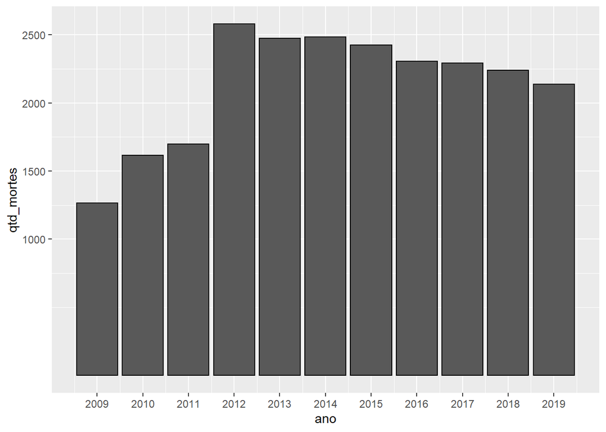

```r
library(ggplot2)
library(scales)

mortes_ano <- aggregate(sigla_uf~ano, data_mortalidade_materna, length)
colnames(mortes_ano) <- c('ano', 'qtd_mortes')

q <- ggplot(data = mortes_ano, mapping = aes(x = ano, y = qtd_mortes)) + geom_bar(stat = 'identity', position='dodge', colour='black') + scale_x_continuous(breaks=c(2009,2010,2011,2012,2013,2014,2015,2016,2017,2018,2019)) + scale_y_continuous(breaks=c(1000, 1500, 2000, 2500))
q
```

Com isso, vamos ver como está distribuída a variável obito_parto:

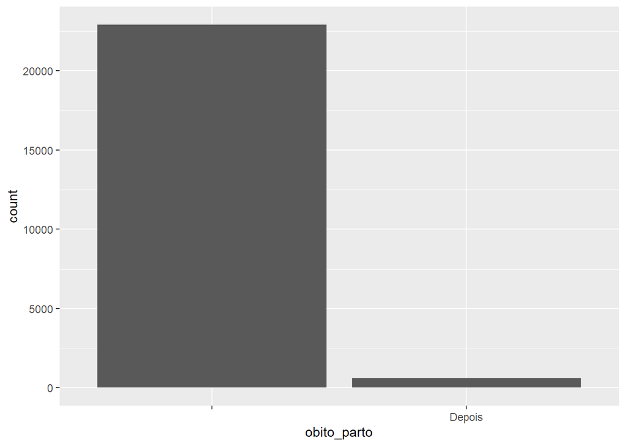

```r
library(ggplot2)

ggplot(data = data_mortalidade_materna, aes(x = obito_parto)) +
    geom_bar()
```

Podemos ver também a distribuição da variável obito_gravidez:

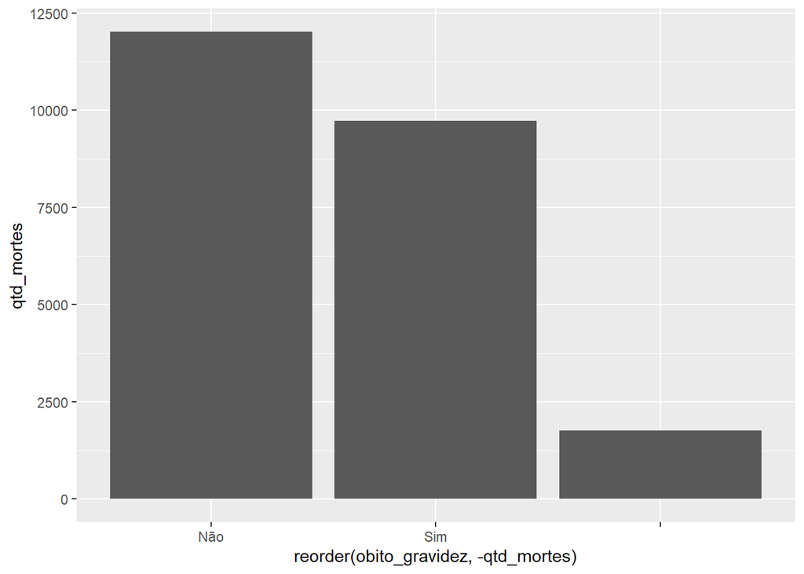

```r
library(ggplot2)

df_obito_gravidez <- aggregate(sigla_uf~obito_gravidez, data_mortalidade_materna, length)
colnames(df_obito_gravidez) <- c('obito_gravidez', 'qtd_mortes')


ggplot(data = df_obito_gravidez, aes(x = reorder(obito_gravidez, -qtd_mortes), y=qtd_mortes)) + geom_bar(stat = 'identity')
```

Temos também a variável obito_puerperio:

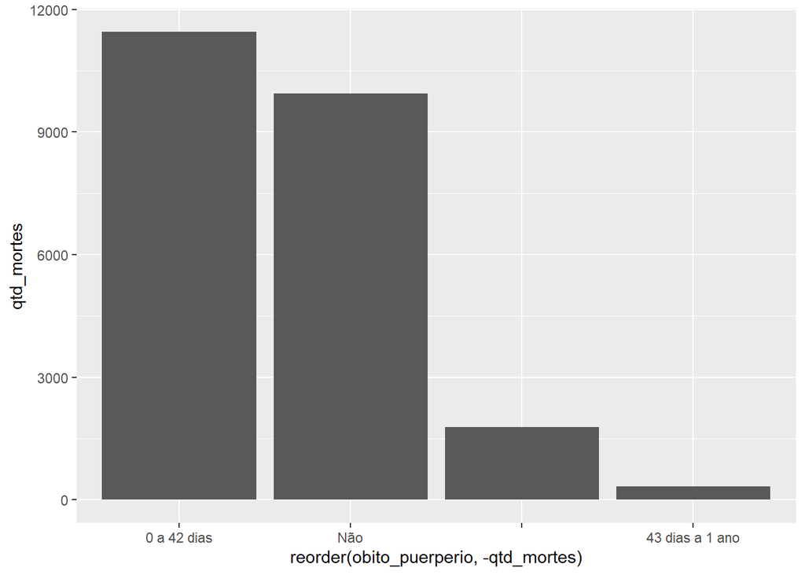

```r
library(ggplot2)

df_obito_puerperio <- aggregate(sigla_uf~obito_puerperio, data_mortalidade_materna, length)
colnames(df_obito_puerperio) <- c('obito_puerperio', 'qtd_mortes')


ggplot(data = df_obito_puerperio, aes(x = reorder(obito_puerperio, -qtd_mortes), y=qtd_mortes)) + geom_bar(stat = 'identity')
```

Agora, vamos ver a distribuição da variável assistência médica:

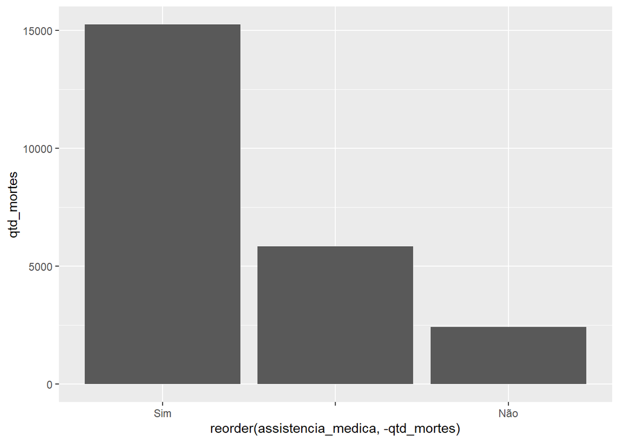

```r
library(ggplot2)

df_assistencia_medica <- aggregate(sigla_uf~assistencia_medica, data_mortalidade_materna, length)
colnames(df_assistencia_medica) <- c('assistencia_medica', 'qtd_mortes')

ggplot(data = df_assistencia_medica, aes(x = reorder(assistencia_medica, -qtd_mortes), y=qtd_mortes)) + geom_bar(stat = 'identity')
```

Agora, vamos analisar a distribuição de raças:

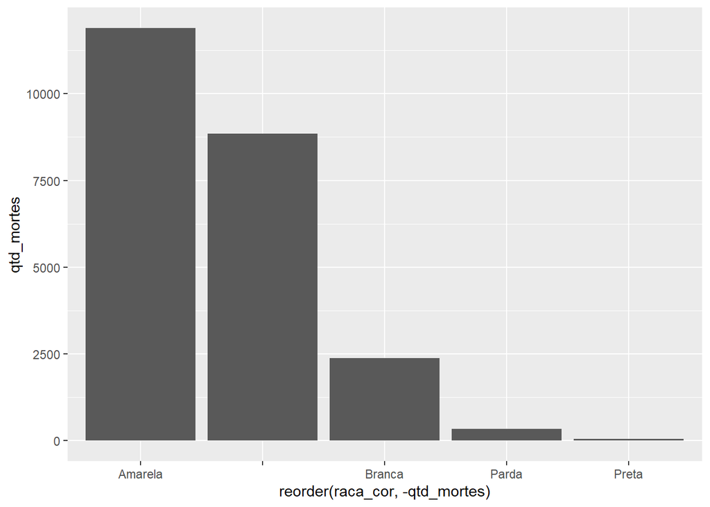

```r
library(ggplot2)

df_raca_cor <- aggregate(sigla_uf~raca_cor, data_mortalidade_materna, length)
colnames(df_raca_cor) <- c('raca_cor', 'qtd_mortes')

ggplot(data = df_raca_cor, aes(x = reorder(raca_cor, -qtd_mortes), y=qtd_mortes)) + geom_bar(stat = 'identity')
```

Temos também por estado civil:

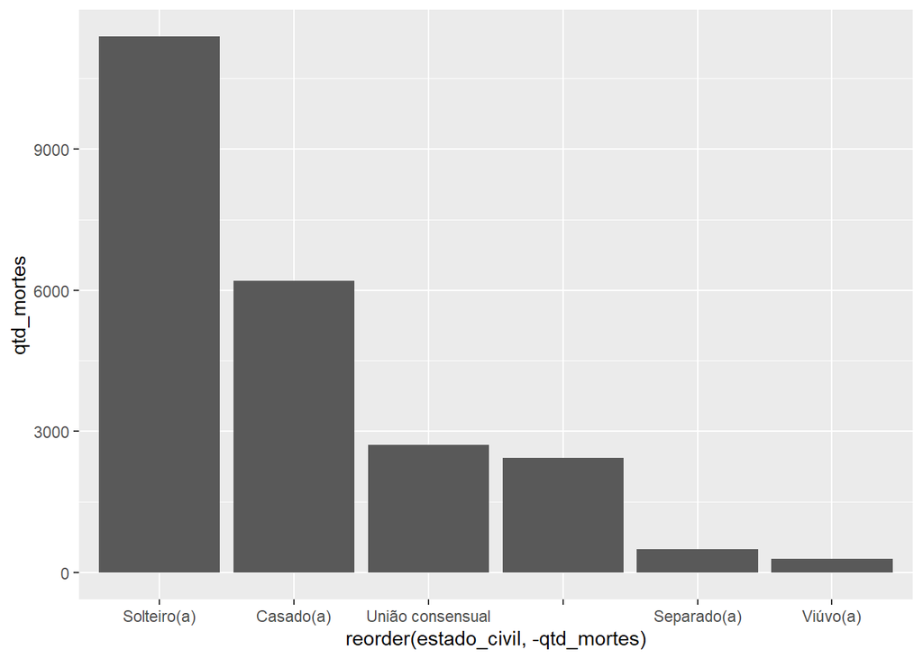

```r
library(ggplot2)

df_estado_civil <- aggregate(sigla_uf~estado_civil, data_mortalidade_materna, length)
colnames(df_estado_civil) <- c('estado_civil', 'qtd_mortes')


ggplot(data = df_estado_civil, aes(x = reorder(estado_civil, -qtd_mortes), y=qtd_mortes)) + geom_bar(stat = 'identity')
```

Por escolaridade, temos:

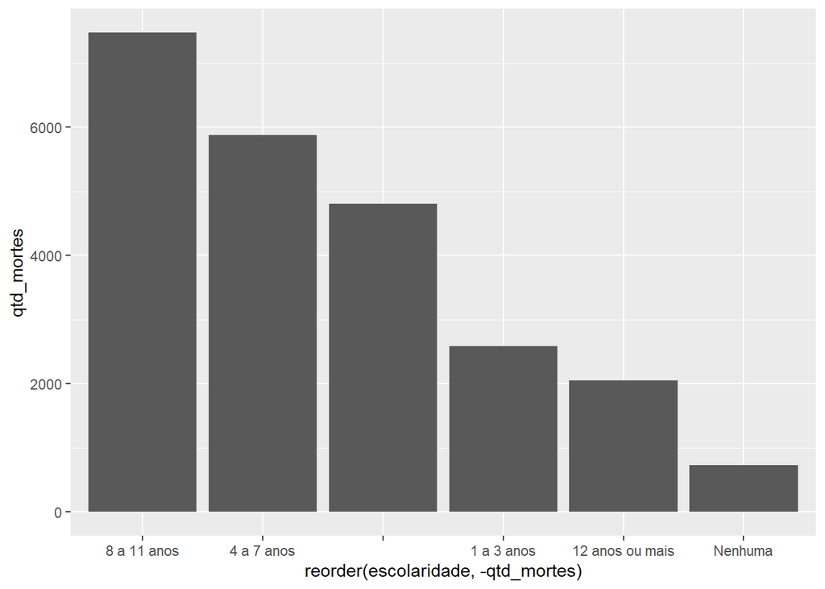

```r
library(ggplot2)

df_escolaridade <- aggregate(sigla_uf~escolaridade, data_mortalidade_materna, length)
colnames(df_escolaridade) <- c('escolaridade', 'qtd_mortes')

ggplot(data = df_escolaridade, aes(x = reorder(escolaridade, -qtd_mortes), y=qtd_mortes)) + geom_bar(stat = 'identity')
```

Agora, veremos o tipo de morte:

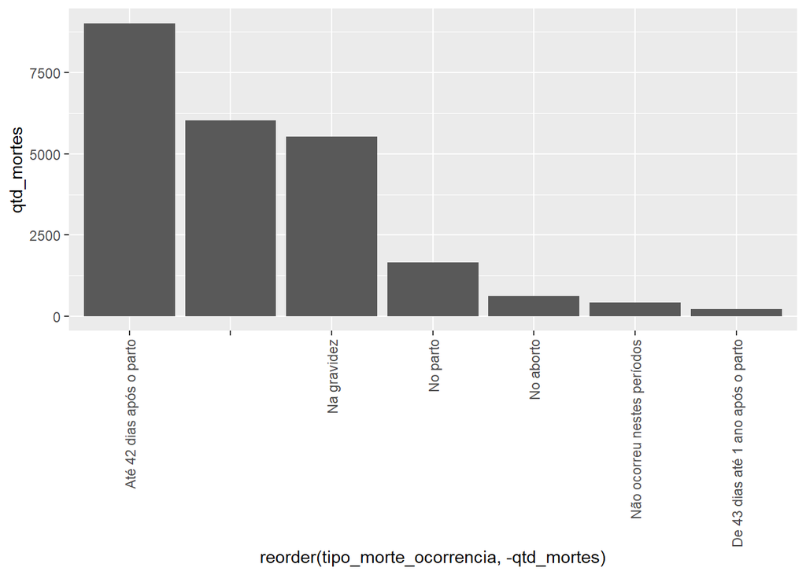

```r
library(ggplot2)

df_tipo_morte <- aggregate(sigla_uf~tipo_morte_ocorrencia, data_mortalidade_materna, length)
colnames(df_tipo_morte) <- c('tipo_morte_ocorrencia', 'qtd_mortes')

ggplot(data = df_tipo_morte, aes(x = reorder(tipo_morte_ocorrencia, -qtd_mortes), y=qtd_mortes)) + geom_bar(stat = 'identity') + theme(axis.text.x = element_text(angle = 90, vjust = 0.5, hjust=1))
```

Agora, vamos analisar as faixas etárias das mortes:

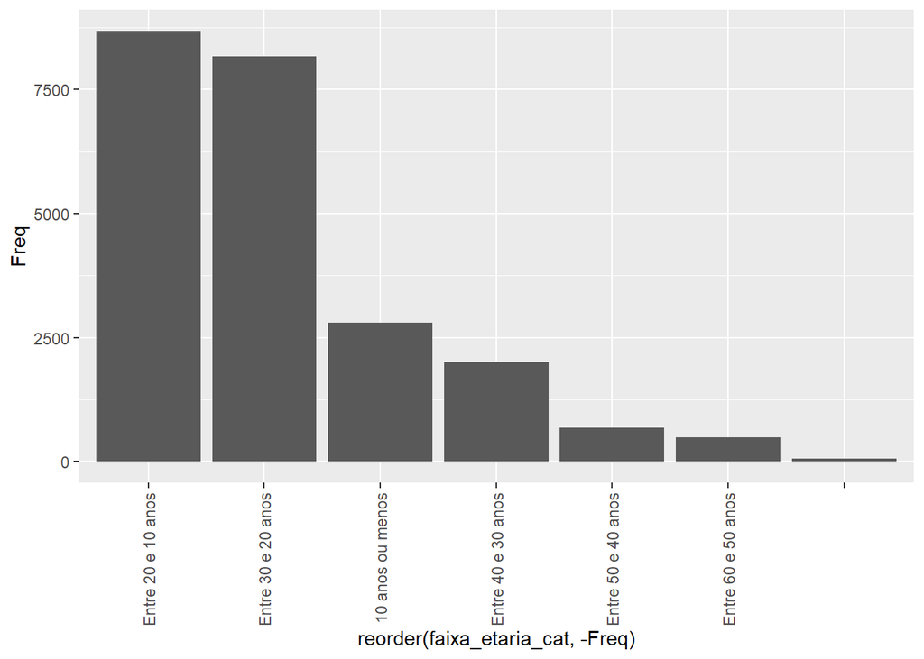

```r
library(ggplot2)

idades_obitos <- round((as.Date(data_mortalidade_materna$data_obito) - as.Date(data_mortalidade_materna$data_nascimento))/365, 0)

faixa_etaria <- findInterval(idades_obitos, c(10, 20, 30, 40, 50, 60, 70, 80, 90, 100, 110, 120))

faixa_etaria_cat <- c()
for (i in 1:length(faixa_etaria)){
  if(is.na(faixa_etaria[i])){
    faixa_etaria_cat <- append(faixa_etaria_cat, ' ')
  } else if(faixa_etaria[i] == 1){
    faixa_etaria_cat <- append(faixa_etaria_cat, '10 anos ou menos')
  } else if (faixa_etaria[i] == 2){
    faixa_etaria_cat <- append(faixa_etaria_cat, 'Entre 20 e 10 anos')
  } else if (faixa_etaria[i] == 3){
    faixa_etaria_cat <- append(faixa_etaria_cat, 'Entre 30 e 20 anos')
  } else if (faixa_etaria[i] == 4){
    faixa_etaria_cat <- append(faixa_etaria_cat, 'Entre 40 e 30 anos')
  } else if (faixa_etaria[i] == 5){
    faixa_etaria_cat <- append(faixa_etaria_cat, 'Entre 50 e 40 anos')
  } else if (faixa_etaria[i] == 6){
    faixa_etaria_cat <- append(faixa_etaria_cat, 'Entre 60 e 50 anos')
  } else if (faixa_etaria[i] == 7){
    faixa_etaria_cat <- append(faixa_etaria_cat, 'Entre 70 e 60 anos')
  } else if (faixa_etaria[i] == 8){
    faixa_etaria_cat <- append(faixa_etaria_cat, 'Entre 80 e 70 anos')
  } else if (faixa_etaria[i] == 9){
    faixa_etaria_cat <- append(faixa_etaria_cat, 'Entre 90 e 80 anos')
  }
}

df_faixa_etaria_cat <- as.data.frame(table(faixa_etaria_cat))

ggplot(data = df_faixa_etaria_cat, aes(x = reorder(faixa_etaria_cat, -Freq), y=Freq)) + geom_bar(stat = 'identity') + theme(axis.text.x = element_text(angle = 90, vjust = 0.5, hjust=1))
```

Primeiramente, vamos criar uma tabela de contingência entre as variáveis “raca_cor” e “tipo_morte_ocorrencia”:

```r
data2 <- data_mortalidade_materna[, c("raca_cor", "tipo_morte_ocorrencia")]

conTable = table(data2)
conTable
```

```
##          tipo_morte_ocorrencia
## raca_cor       Até 42 dias após o parto De 43 dias até 1 ano após o parto
##           2382                     3329                                83
##   Amarela 2976                     4602                               118
##   Branca   572                      947                                23
##   Parda     85                      120                                 3
##   Preta     11                       27                                 0
##          tipo_morte_ocorrencia
## raca_cor  Na gravidez Não ocorreu nestes períodos No aborto No parto
##                  2130                         138       227      560
##   Amarela        2755                         228       317      894
##   Branca          556                          43        74      162
##   Parda            69                          12         9       43
##   Preta            13                           1         1        5
```

Testaremos a independências das variáveis utilizado o teste do chi-quadrado. Definiremos a hipótese nula e alternativa e especificaremos o nível de significância da seguinte forma:

$$H_0 = \text{raca_cor e
tipo_morte_ocorrencia são independentes}$$
$$H_a = \text{raca_cor e tipo_morte_ocorrencia não
são independentes}$$
O nível de significância é dado por
$$\alpha = 0.05$$
. Aplicando a função do chi-quadrado, temos:

```r
chisq.test(conTable)
```

```
##
##  Pearson's Chi-squared test
##
## data:  conTable
## X-squared = 56.907, df = 24, p-value = 0.0001722
```

Como o p-valor é menor que o alfa, a hipótese nula é rejeitada. Portanto, concluímos que raca_cor e tipo_morte_ocorrencia não são independentes.

Agora, vamos medir a associação entre as duas variáveis. Para isso, utilizaremos o V de Cramer. Os valores do V de Cramer variam entre 0 e 1. Os valores altos do V de Cramer indicam uma relação mais forte entre as variáveis, e os valores menores para o V indicam uma relação fraca.

Aplicando a função do V de Cramer, temos:

```r
library(rcompanion)

cramerV(conTable)
```

```
## Cramer V
##   0.0246
```

Com isso, temos que o V de Cramer indica que raca_cor possui um efeito baixo e estatisticamente significante em tipo_morte_ocorrencia.

```r
library(sqldf)
relacao_raca_morte = sqldf('SELECT raca_cor, tipo_morte_ocorrencia, count(tipo_morte_ocorrencia) AS QTD FROM data2 GROUP BY raca_cor, tipo_morte_ocorrencia order by count(tipo_morte_ocorrencia) DESC')
relacao_raca_morte
```

| raca_cor | tipo_morte_ocorrencia | QTD |
| --- | --- | --- |
| Amarela | Até 42 dias após o parto | 4602 |
|  | Até 42 dias após o parto | 3329 |
| Amarela |  | 2976 |
| Amarela | Na gravidez | 2755 |
|  |  | 2382 |
|  | Na gravidez | 2130 |
| Branca | Até 42 dias após o parto | 947 |
| Amarela | No parto | 894 |
| Branca |  | 572 |
|  | No parto | 560 |

[output cut: 24 more lines]

Agora, vamos criar uma tabela de contingência entre as variáveis “estado_civil” e “tipo_morte_ocorrencia”:

```r
data2 <- data_mortalidade_materna[, c("estado_civil", "tipo_morte_ocorrencia")]
#data2 <- data2[!data2$estado_civil == " ", ]
#data2 <- data2[!data2$tipo_morte_ocorrencia == " ", ]

conTable = table(data2)
conTable
```

```
##                   tipo_morte_ocorrencia
## estado_civil            Até 42 dias após o parto
##                     503                     1099
##   Casado(a)        1660                     2485
##   Separado(a)       110                      149
##   Solteiro(a)      3319                     3973
##   União consensual  393                     1260
##   Viúvo(a)           41                       59
##                   tipo_morte_ocorrencia
## estado_civil       De 43 dias até 1 ano após o parto Na gravidez
##                                                   14         484
##   Casado(a)                                       64        1304
##   Separado(a)                                      4         181
##   Solteiro(a)                                    119        2783
##   União consensual                                26         611
##   Viúvo(a)                                         0         160
##                   tipo_morte_ocorrencia
## estado_civil       Não ocorreu nestes períodos No aborto No parto
##                                             31        67      234
##   Casado(a)                                103       135      441
##   Separado(a)                                8        15       33
##   Solteiro(a)                              205       334      648
##   União consensual                          71        66      284
##   Viúvo(a)                                   4        11       24
```

Testaremos a independências das variáveis utilizado o teste do chi-quadrado. Definiremos a hipótese nula e alternativa e especificaremos o nível de significância da seguinte forma:

$$H_0 = \text{estado_civil e
tipo_morte_ocorrencia são independentes}$$
$$H_a = \text{estado_civil e tipo_morte_ocorrencia
não são independentes}$$
O nível de significância é dado por
$$\alpha = 0.05$$
. Aplicando a função do chi-quadrado, temos:

```r
chisq.test(conTable)
```

```
##
##  Pearson's Chi-squared test
##
## data:  conTable
## X-squared = 700.18, df = 30, p-value < 2.2e-16
```

Como o p-valor é menor que o alfa, a hipótese nula é rejeitada. Portanto, concluímos que estado_civil e tipo_morte_ocorrencia não são independentes.

Agora, vamos medir a associação entre as duas variáveis. Aplicando a função de V de Cramer, temos:

```r
library(rcompanion)

cramerV(conTable)
```

```
## Cramer V
##  0.07717
```

Com isso, temos que o V de Cramer indica que estado_civil possui um efeito baixo e estatisticamente significante em tipo_morte_ocorrencia.

```r
library(sqldf)
relacao_estadocivil_morte = sqldf('SELECT estado_civil, tipo_morte_ocorrencia, count(tipo_morte_ocorrencia) AS QTD FROM data2 GROUP BY estado_civil, tipo_morte_ocorrencia order by count(tipo_morte_ocorrencia) DESC')
relacao_estadocivil_morte
```

| estado_civil | tipo_morte_ocorrencia | QTD |
| --- | --- | --- |
| Solteiro(a) | Até 42 dias após o parto | 3973 |
| Solteiro(a) |  | 3319 |
| Solteiro(a) | Na gravidez | 2783 |
| Casado(a) | Até 42 dias após o parto | 2485 |
| Casado(a) |  | 1660 |
| Casado(a) | Na gravidez | 1304 |
| União consensual | Até 42 dias após o parto | 1260 |
|  | Até 42 dias após o parto | 1099 |
| Solteiro(a) | No parto | 648 |
| União consensual | Na gravidez | 611 |

[output cut: 31 more lines]

Agora, vamos criar uma tabela de contingência entre as variáveis “escolaridade” e “tipo_morte_ocorrencia”:

```r
data2 <- data_mortalidade_materna[, c("escolaridade", "tipo_morte_ocorrencia")]
#data2 <- data2[!data2$escolaridade == " ", ]
#data2 <- data2[!data2$tipo_morte_ocorrencia == " ", ]

conTable = table(data2)
conTable
```

```
##                  tipo_morte_ocorrencia
## escolaridade           Até 42 dias após o parto
##                   1421                     1766
##   1 a 3 anos       679                      833
##   12 anos ou mais  485                      938
##   4 a 7 anos      1642                     2078
##   8 a 11 anos     1618                     3230
##   Nenhuma          181                      180
##                  tipo_morte_ocorrencia
## escolaridade      De 43 dias até 1 ano após o parto Na gravidez
##                                                  37         990
##   1 a 3 anos                                     24         754
##   12 anos ou mais                                16         414
##   4 a 7 anos                                     63        1448
##   8 a 11 anos                                    81        1661
##   Nenhuma                                         6         256
##                  tipo_morte_ocorrencia
## escolaridade      Não ocorreu nestes períodos No aborto No parto
##                                            78       118      391
##   1 a 3 anos                               48        62      184
##   12 anos ou mais                          30        50      120
##   4 a 7 anos                              107       158      378
##   8 a 11 anos                             148       220      514
##   Nenhuma                                  11        20       77
```

Testaremos a independências das variáveis utilizado o teste do chi-quadrado. Definiremos a hipótese nula e alternativa e especificaremos o nível de significância da seguinte forma:

$$H_0 = \text{escolaridade e
tipo_morte_ocorrencia são independentes}$$
$$H_a = \text{escolaridade e tipo_morte_ocorrencia
não são independentes}$$
O nível de significância é dado por
$$\alpha = 0.05$$
. Aplicando a função do chi-quadrado, temos:

```r
chisq.test(conTable)
```

```
##
##  Pearson's Chi-squared test
##
## data:  conTable
## X-squared = 397.41, df = 30, p-value < 2.2e-16
```

Como o p-valor é menor que o alfa, a hipótese nula é rejeitada. Portanto, concluímos que escolaridade e tipo_morte_ocorrencia não são independentes.

Agora, vamos medir a associação entre as duas variáveis. Aplicando a função de V de Cramer, temos:

```r
library(rcompanion)

cramerV(conTable)
```

```
## Cramer V
##  0.05814
```

Com isso, temos que o V de Cramer indica que escolaridade possui um efeito baixo e estatisticamente significante em tipo_morte_ocorrencia.

```r
library(sqldf)
relacao_escolaridade_morte = sqldf('SELECT escolaridade, tipo_morte_ocorrencia, count(tipo_morte_ocorrencia) AS QTD FROM data2 GROUP BY escolaridade, tipo_morte_ocorrencia order by count(tipo_morte_ocorrencia) DESC')
relacao_escolaridade_morte
```

| escolaridade | tipo_morte_ocorrencia | QTD |
| --- | --- | --- |
| 8 a 11 anos | Até 42 dias após o parto | 3230 |
| 4 a 7 anos | Até 42 dias após o parto | 2078 |
|  | Até 42 dias após o parto | 1766 |
| 8 a 11 anos | Na gravidez | 1661 |
| 4 a 7 anos |  | 1642 |
| 8 a 11 anos |  | 1618 |
| 4 a 7 anos | Na gravidez | 1448 |
|  |  | 1421 |
|  | Na gravidez | 990 |
| 12 anos ou mais | Até 42 dias após o parto | 938 |

[output cut: 32 more lines]

Agrupando mortalidade materna por estado:

```r
mortes_por_estado <- aggregate(data_mortalidade_materna[,2], list(data_mortalidade_materna$sigla_uf), length)
mortes_por_estado[order(mortes_por_estado$x, decreasing=TRUE), ]
```

|  | Group.1 | x |
| --- | --- | --- |
| 26 | SP | 4178 |
| 11 | MG | 2163 |
| 19 | RJ | 2097 |
| 5 | BA | 1756 |
| 14 | PA | 1301 |
| 10 | MA | 1234 |
| 16 | PE | 1117 |
| 6 | CE | 1111 |
| 18 | PR | 1037 |
| 9 | GO | 839 |

[output cut: 17 more lines]

Maranhão é o 12º estado mais populoso do Brasil e é o 6º na lista acima. Os demais estados parecem fazer sentido em relação as suas distribuições populacionais.

```r
mortes_sp = data_mortalidade_materna[data_mortalidade_materna$sigla_uf=="SP",]
tipos_mortes_sp <- table(mortes_sp$tipo_morte_ocorrencia)
sort(tipos_mortes_sp, decreasing=TRUE)
```

```
##
##          Até 42 dias após o parto
##                              1680                              1036
##                       Na gravidez                          No parto
##                              1023                               242
##                         No aborto       Não ocorreu nestes períodos
##                                89                                71
## De 43 dias até 1 ano após o parto
##                                37
```

Podemos agrupar pelas cidades de São Paulo, obtendo:

```r
mortes_cidades_sp <- aggregate(mortes_sp[,11], list(mortes_sp$municipio_ocorrencia), length)
mortes_cidades_sp[order(mortes_cidades_sp$x, decreasing=TRUE), ]
```

|  | Group.1 | x |
| --- | --- | --- |
| 238 | São Paulo | 1051 |
| 98 | Guarulhos | 163 |
| 46 | Campinas | 123 |
| 227 | Santos | 92 |
| 247 | Sorocaba | 90 |
| 225 | Santo André | 86 |
| 138 | Jundiaí | 74 |
| 155 | Mogi das Cruzes | 73 |
| 168 | Osasco | 66 |
| 205 | Ribeirão Preto | 62 |

[output cut: 263 more lines]

Agora vamos ver em MA:

```r
mortes_ma = data_mortalidade_materna[data_mortalidade_materna$sigla_uf=="MA",]
tipos_mortes_ma <- table(mortes_ma$tipo_morte_ocorrencia)
sort(tipos_mortes_ma, decreasing = TRUE)
```

```
##
##          Até 42 dias após o parto
##                               386                               319
##                       Na gravidez                          No parto
##                               265                               152
##       Não ocorreu nestes períodos                         No aborto
##                                65                                37
## De 43 dias até 1 ano após o parto
##                                10
```

Podemos agrupar pelas cidades do Maranhão, obtendo:

```r
mortes_cidades_ma <- aggregate(mortes_ma[,11], list(mortes_ma$municipio_ocorrencia), length)
mortes_cidades_ma[order(mortes_cidades_ma$x, decreasing=TRUE), ]
```

|  | Group.1 | x |
| --- | --- | --- |
| 111 | São Luís | 356 |
| 55 | Imperatriz | 151 |
| 29 | Caxias | 67 |
| 122 | Teresina | 52 |
| 90 | Pinheiro | 33 |
| 94 | Presidente Dutra | 27 |
| 32 | Chapadinha | 24 |
| 51 | Grajaú | 22 |
| 98 | Santa Inês | 22 |
| 14 | Balsas | 19 |

[output cut: 126 more lines]

Agora vamos agrupar por regiões:

```r
mortes_por_regiao <- aggregate(data_mortalidade_materna[,42], list(data_mortalidade_materna$regiao), length)
mortes_por_regiao[order(mortes_por_regiao$x, decreasing=TRUE), ]
```

|  | Group.1 | x |
| --- | --- | --- |
| 4 | Sudeste | 8885 |
| 2 | Nordeste | 7383 |
| 3 | Norte | 2911 |
| 5 | Sul | 2362 |
| 1 | Centro-Oeste | 1974 |